# 1. Recall Perceptron

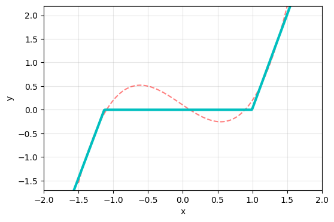

```python
x1p = np.arange(-2, 2, 0.01).reshape(-1, 1)
x2p = weights2[0]*relu(weights[0][0]*x1p + biases[0]) + weights2[1]*relu(weights[0][1]*x1p + biases[1])

plt.figure(figsize = (6, 4))
plt.xlim([-2, 2])
plt.ylim([-1.7, 2.2])
plt.plot(real_x, real_y, '--', color = 'red', alpha = 0.5)
plt.plot(x1p, x2p, 'c', linewidth = 3)
plt.xlabel('x')
plt.ylabel('y')
plt.grid(alpha = 0.3)
plt.show()
```

**Four Neurons with ReLU**

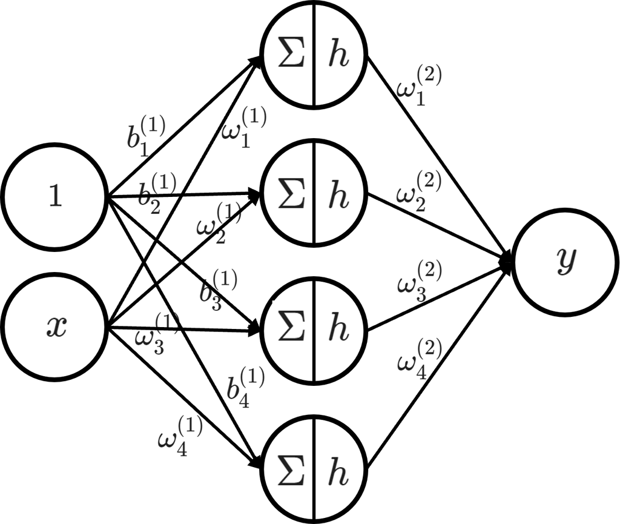

$$\hat{y} = \omega_1^{(2)} \left( h \left( \omega_1^{(1)} x + b_1^{(1)} \right) \right) + \omega_2^{(2)} \left( h \left( \omega_2^{(1)} x + b_2^{(1)} \right) \right) + \omega_3^{(2)} \left( h \left( \omega_3^{(1)} x + b_3^{(1)} \right)\right) + \omega_4^{(2)} \left( h \left( \omega_4^{(1)} x + b_4^{(1)} \right) \right) $$

```python
model_4 = tf.keras.models.Sequential([
    tf.keras.layers.Dense(units = 4, activation = 'relu'),
    tf.keras.layers.Dense(units = 1, use_bias = False)
])

model_4.compile(optimizer = 'adam',
              loss = 'mse')

model_4.fit(train_x, train_y, epochs = 4000, verbose = 0)
```

```
<keras.src.callbacks.History at 0x78ea68189b70>
```

```python
weights = model_4.layers[0].get_weights()[0]
biases = model_4.layers[0].get_weights()[1]
weights2 = model_4.layers[1].get_weights()[0]
```

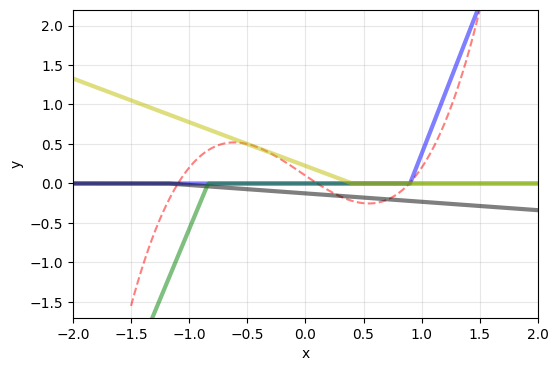

```python
x1p = np.arange(-2, 2, 0.01).reshape(-1, 1)
x2p = weights2[0]*relu(weights[0][0]*x1p + biases[0])
x3p = weights2[1]*relu(weights[0][1]*x1p + biases[1])
x4p = weights2[2]*relu(weights[0][2]*x1p + biases[2])
x5p = weights2[3]*relu(weights[0][3]*x1p + biases[3])

plt.figure(figsize = (6, 4))
plt.xlim([-2, 2])
plt.ylim([-1.7, 2.2])
plt.plot(real_x, real_y, '--', color = 'red', alpha = 0.5)
plt.plot(x1p, x2p, 'b', linewidth = 3, alpha = 0.5)
plt.plot(x1p, x3p, 'k', linewidth = 3, alpha = 0.5)
plt.plot(x1p, x4p, 'g', linewidth = 3, alpha = 0.5)
plt.plot(x1p, x5p, 'y', linewidth = 3, alpha = 0.5)
plt.xlabel('x')
plt.ylabel('y')
plt.grid(alpha = 0.3)
plt.show()
```

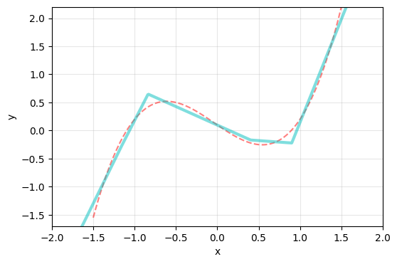

```python
x1p = np.arange(-2, 2, 0.01).reshape(-1, 1)
x2p = weights2[0]*relu(weights[0][0]*x1p + biases[0]) + weights2[1]*relu(weights[0][1]*x1p + biases[1]) + weights2[2]*relu(weights[0][2]*x1p + biases[2]) + weights2[3]*relu(weights[0][3]*x1p + biases[3])

plt.figure(figsize = (6, 4))
plt.xlim([-2, 2])
plt.ylim([-1.7, 2.2])
plt.plot(real_x, real_y, '--', color = 'red', alpha = 0.5)
plt.plot(x1p, x2p, 'c', linewidth = 3)
plt.xlabel('x')
plt.ylabel('y')
plt.grid(alpha = 0.3)
plt.show()
```

**100 Neurons with ReLU**

```python
model_100 = tf.keras.models.Sequential([
    tf.keras.layers.Dense(units = 100, activation = 'relu'),
    tf.keras.layers.Dense(units = 1, use_bias = False)
])

model_100.compile(optimizer = 'adam',
              loss = 'mse')

model_100.fit(train_x, train_y, epochs = 1000, verbose = 0)
```

```
<keras.src.callbacks.History at 0x7cba3e13b7f0>
```

```python
weights = model_100.layers[0].get_weights()[0]
biases = model_100.layers[0].get_weights()[1]
weights2 = model_100.layers[1].get_weights()[0]
```

```python
x1p = np.arange(-2, 2, 0.01).reshape(-1, 1)
x2p = 0

for i in range(100):
    x2p += weights2[i]*relu(weights[0][i]*x1p + biases[i])
```

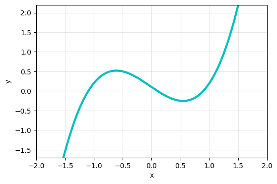

```python
plt.figure(figsize = (6, 4))
plt.xlim([-2, 2])
plt.ylim([-1.7, 2.2])
plt.plot(real_x, real_y, '--', color = 'red', alpha = 0.5)
plt.plot(x1p, x2p, 'c', linewidth = 3)
plt.xlabel('x')
plt.ylabel('y')
plt.grid(alpha = 0.3)
plt.show()
```

Key Points:

- Each curve represents the output of a single ReLU neuron in response to the input feature $x$.
- The activation values are zero for certain ranges of $x$, indicating that the neuron is "inactive" in those regions.
- The piecewise linear segments created by the ReLU activations contribute to forming the overall non-linear regression curve.

This illustrates how the hidden layer's neurons, each applying ReLU activation, form different regions of the input space and collectively approximate the non-linear function.

# 5. Artificial Neural Networks

So far, we have conducted an in-depth examination of how an artificial neural network (ANN) operates at a micro level, focusing on the underlying mechanisms of individual neurons, layers, and their interactions. Having developed these foundational insights and intuitions, we are now in a position to broaden our perspective and analyze the ANN as a cohesive system, considering its overall architecture, functionality, and the role each component plays in contributing to the network's collective decision-making process.

**Complex/Nonlinear Universal Function Approximator**

- ANNs are powerful universal function approximators that can model both linear and nonlinear relationships.
- By stacking layers of neurons and using non-linear activation functions, ANNs can represent highly complex mappings, making them suitable for a wide range of tasks, such as image recognition, speech processing, and time-series predictions.

**ANN Architecture**

- ANNs are typically organized as feedforward networks with layers that are fully connected. In these networks:
  - Each neuron in a layer receives inputs from all neurons in the previous layer.
  - The network propagates information forward, from input to output, without loops.
- Each layer performs a linear transformation of the input.
- Linear connections alone cannot capture complex relationships; this is where non-linear activation functions become essential.
- Each neuron applies a non-linear activation function to the weighted sum of its inputs
- These nonlinear neurons allow ANNs to learn non-linear decision boundaries, making them capable of solving complex, non-linearly separable problems.

**Hidden Layers and Autonomous Feature Learning**

- Hidden layers are the intermediate layers between the input and output layers in a neural network.
- Each hidden layer learns intermediate representations or features from the input data.
  - Shallow networks have fewer hidden layers and may struggle with highly complex patterns.
  - Deep networks with many hidden layers (Deep Neural Networks) can model highly intricate relationships but require large datasets and longer training times.
- The neurons in the hidden layers create intermediate transformations that allow the network to construct hierarchical feature representations, leading to improved performance for complex tasks.
- Unlike traditional machine learning models that rely on manual feature extraction, ANNs can automatically learn features from raw data.
  - Each layer in an ANN learns increasingly abstract features.
  - This autonomous feature learning makes ANNs robust across diverse domains and applications, eliminating the need for domain-specific feature engineering.

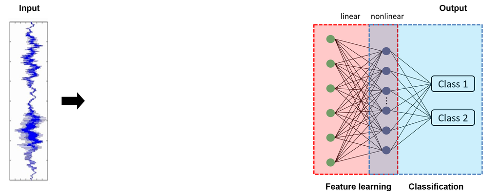


# 6. ANN Learning

Now that we understand how an Artificial Neural Network (ANN) works, the next step is to determine the unknown parameters (the weights and biases) from the data. Once the structure of the ANN is designed, these parameters must be learned through training. In the following, we will discuss how this learning process takes place.

To begin with the conclusion, the learning process is performed using the **backpropagation algorithm**. Before diving into the details of backpropagation, it is essential to first review "recursive algorithms" and "dynamic programming", as they form the foundational concepts necessary for understanding backpropagation.

```python
from IPython.display import YouTubeVideo
YouTubeVideo('mGuXwSbantc', width="560", height="315", frameborder="0")
```

[video not shown]

## 6.1. Recursive Algorithm

- A fundamental concept in computer science:
  - Recursive algorithms play a pivotal role in solving problems by breaking them down into smaller, manageable subproblems.
- Subproblem-based approach:
  - The solution to the main problem depends on solving smaller instances of the same problem (subproblems).
- Self-referential function calls:
  - A recursive function calls itself with a modified input until reaching a base case.
  - This mechanism does not directly occur in the physical world, making recursion a unique and abstract computational concept.

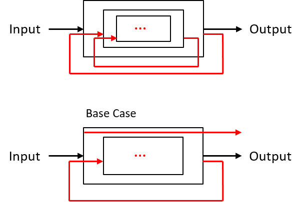

```python
%%html
<iframe src="https://www.youtube.com/embed/t4MSwiqfLaY?rel=0"
width="560" height="315" frameborder="0" allowfullscreen></iframe>
```

[video not shown]

- Factorial example

$$n ! = n \cdot (n-1) \cdots 2 \cdot 1$$

```python
n = 5

m = 1
for i in range(n):
    m = m*(i+1)

print(m)
```

```
120
```

```python
def fac(n):
    if n == 1:
        return 1
    else:
        return n*fac(n-1)
```

```python
# recursive

fac(5)
```

```
120
```

## 6.2. Dynamic Programming

Dynamic programming (DP) is a powerful algorithmic technique used to solve optimization problems by breaking them down into "overlapping" subproblems. It is particularly effective for problems with overlapping subproblems and optimal substructure, where solutions to smaller subproblems can be reused to build the solution to the overall problem.

- Optimal Substructure
  - A problem exhibits optimal substructure if the optimal solution to the problem can be constructed from the optimal solutions of its subproblems.
  - Example: In the shortest path problem, the shortest path from point A to point C passing through point B consists of the shortest path from A to B combined with the shortest path from B to C.
- Overlapping Subproblems
  - A problem has overlapping subproblems if the same subproblems are solved multiple times during the computation.
  - Instead of solving the same subproblem repeatedly, dynamic programming stores the results of solved subproblems in a lookup table (memoization) for future reuse.

Let’s discuss dynamic programming using the Fibonacci sequence as an example:

$$ \begin{align*} F_1 &= F_2 = 1 \\ F_n &= F_{n-1} + F_{n-2} \end{align*} $$

```python
# naive Fibonacci

def fib(n):
    if n <= 2:
        return 1
    else:
        return fib(n-1) + fib(n-2)
```

```python
fib(10)
```

```
55
```

The naive recursive method performs redundant calculations, repeatedly solving subproblems even when their solutions have already been computed. In contrast, dynamic programming allocates memory to store previously computed results. When a subproblem is encountered, DP first checks whether the result has already been calculated. If so, it retrieves the value from memory, avoiding redundant computations and significantly reducing the overall computational time. This approach exemplifies the trade-off where computational time is saved at the expense of additional memory usage - an illustration of the 'space-for-time' principle.

```python
# Memorized DP Fibonacci

def mfib(n):
    global memo

    if memo[n-1] != 0:
        return memo[n-1]
    elif n <= 2:
        memo[n-1] = 1
        return memo[n-1]
    else:
        memo[n-1] = mfib(n-1) + mfib(n-2)
        return memo[n-1]
```

```python
import numpy as np

n = 10
memo = np.zeros(n)
mfib(n)
```

```
55.0
```

Dynamic Programming (DP) is much faster than a naive recursive algorithm due to its use of memoization to avoid redundant computations.

```python
n = 30
%timeit fib(30)
```

```
332 ms ± 110 ms per loop (mean ± std. dev. of 7 runs, 1 loop each)
```

```python
memo = np.zeros(n)
%timeit mfib(30)
```

```
389 ns ± 5.28 ns per loop (mean ± std. dev. of 7 runs, 1000000 loops each)
```

**Dynamic Programming (DP) $\approx$ Recursion + Memorization**

Dynamic Programming can be thought of as an optimization technique that enhances recursion by storing the results of previously computed subproblems (memorization). This avoids redundant calculations and improves efficiency.

- Recursion: Breaks a problem down into smaller subproblems and solves them recursively.
- Memorization: Stores the solutions to subproblems in a cache (e.g., a dictionary or array) to reuse them instead of recalculating.

This combination allows DP to solve problems with overlapping subproblems and optimal substructure more efficiently.

## 6.3. Training Neural Networks

Now, let us return to our original problem: learning the weights and biases of a multi-layer perceptron (MLP).

- Learning or estimating weights and biases of multi-layer perceptron from training data
  1. Forward Pass: Input $X$ passes through the network to generate $\hat Y$.
  2. Loss Calculation: The loss function compares $\hat Y$ and $Y$.
  3. Backward Pass: The optimizer computes gradients of the loss concerning the weights.
  4. Weight Update: Weights are adjusted based on the gradients.
  5. Repeat: The process continues until the loss converges or the training reaches a predefined number of iterations.

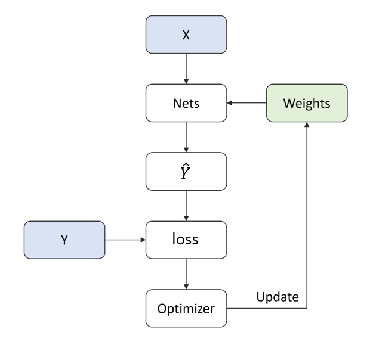

**Loss Function**

- Measures error between target values and predictions

$$ \min_{\omega} \sum_{i=1}^{m}\ell\left( h_{\omega}\left(x^{(i)}\right),y^{(i)}\right)$$

- Example
  - Squared loss (for regression):

    $$ \frac{1}{m} \sum_{i=1}^{m} \left(h_{\omega}\left(x^{(i)}\right) - y^{(i)}\right)^2 $$
  - Cross-entropy (for classification):

    $$ -\frac{1}{m}\sum_{i=1}^{m}y^{(i)}\log\left(h_{\omega}\left(x^{(i)}\right)\right) + \left(1-y^{(i)}\right)\log\left(1-h_{\omega}\left(x^{(i)}\right)\right)$$

**Learning**

- Learning weights and biases from data using gradient descent

$$\omega \leftarrow \omega - \alpha \nabla_{\omega} \ell \left( h_{\omega}\left(x^{(i)}\right), y^{(i)} \right)$$

- $\frac{\partial \ell}{\partial \omega}$: too many computations are required for all $\omega$
- Structural constraints of NN:
  - Composition of functions
  - Chain rule
  - Dynamic programming

**Backpropagation**

Backpropagation is a fundamental algorithm used for training neural networks by adjusting their weights to minimize the loss function. It operates by propagating errors backward through the network, from the output layer to the input layer, using the chain rule of differentiation.

- Forward propagation
  - the initial information propagates up to the hidden units at each layer and finally produces output
- Backpropagation
  - allows the information from the cost to flow backwards through the network in order to compute the gradients
- Chain rule
  - Computing the derivative of the composition of functions

$$ \begin{align*} f(g(x))' &= f'(g(x))g'(x)\\\\ {dz \over dx} &= {dz \over dy} \cdot {dy \over dx}\\ {dz \over dw} &= \left({dz \over dy} \cdot {dy \over dx}\right) \cdot {dx \over dw}\\ {dz \over du} &= \left({dz \over dy} \cdot {dy \over dx} \cdot {dx \over dw}\right) \cdot {dw \over du} \end{align*} $$

- Backpropagation
  - Update weights recursively with memory

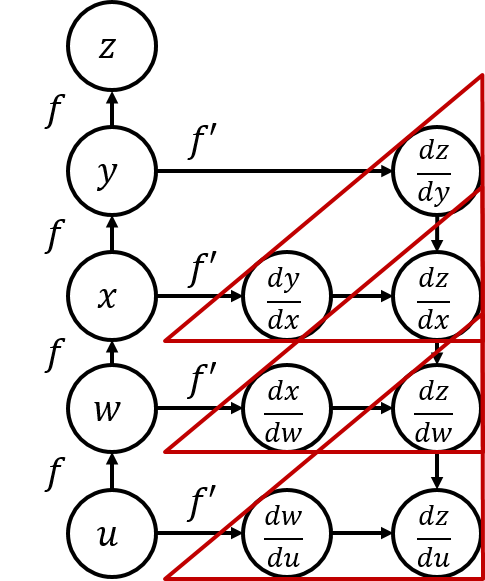

Learning the weights and biases in an artificial neural network (ANN) can be viewed as an optimization process using gradient descent or its variants. However, a significant challenge arises due to the large number of parameters (or unknowns) that need to be estimated, as well as the extensive computations of gradients required during each iteration.

The uniqueness of this problem lies in the sequentially stacked structure of ANN layers, which can be interpreted as a composition of functions. As a result, the computation of gradients involves the application of the chain rule, leading to repeated calculations for intermediate layers.

By computing these gradients in a backward manner, previously computed results can be reused in subsequent steps. This is the fundamental concept behind backpropagation, making it analogous to dynamic programming. The term 'back' in 'backpropagation' highlights this backward computation process, where intermediate results are stored and revisited to avoid redundant computations.

**Summary**

- Learning weights and biases from data using gradient descent $\approx$ backpropagation

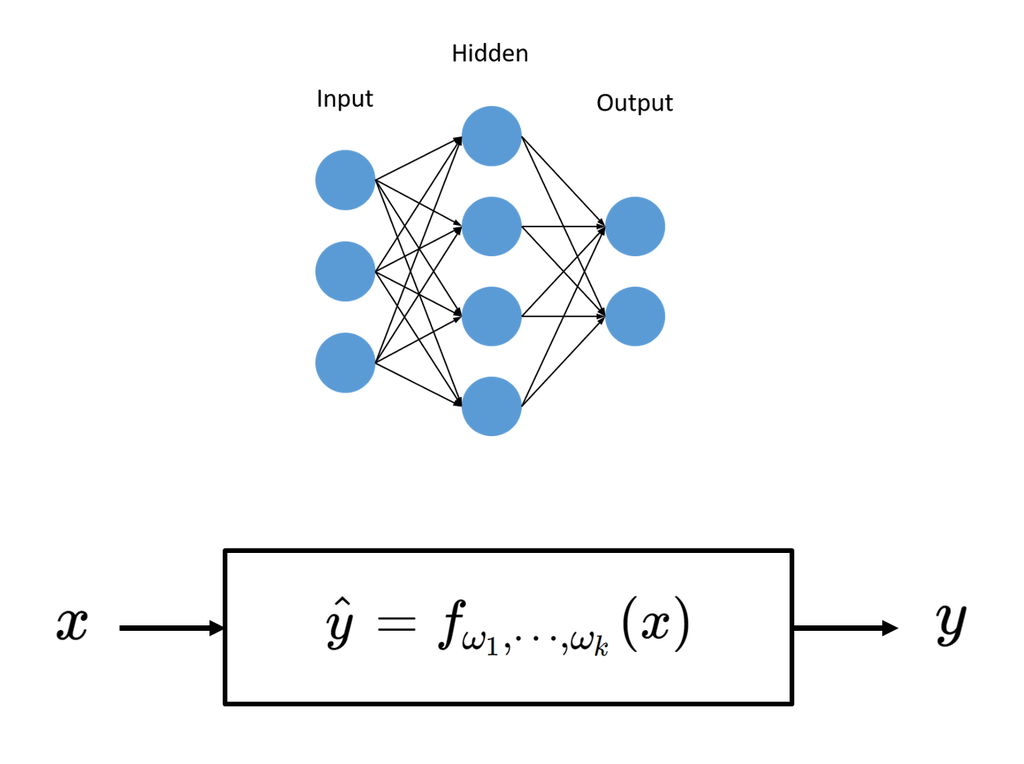

- It is not easy to numerically compute gradients in network in general.
  - The good news: people have already done all the "hardwork" of developing numerical solvers (or libraries)
  - There are a wide range of tools: TensorFlow

## 6.4. Historical Notes

**Backpropagation and Geoffrey Hinton**

Backpropagation (short for "backward propagation of errors") is a core algorithm used to train artificial neural networks (ANNs). It calculates gradients of the loss function with respect to the network’s weights by applying the chain rule of calculus in a systematic, layer-by-layer manner from the output layer back to the input layer. This enables the efficient updating of weights using optimization methods such as gradient descent.

**Why Hinton's Contribution Was Pivotal**

Revival of Neural Networks:

- During the 1980s, symbolic AI dominated the field, and neural networks were seen as outdated and impractical. Hinton’s work with backpropagation demonstrated that neural networks could learn complex representations and outperformed traditional AI approaches on several tasks.

Scalability and Deep Networks:

- Hinton's research showed that backpropagation could handle multi-layer (deep) networks, allowing networks to automatically learn hierarchical representations of features.

The Legacy of Backpropagation:

- The 1986 breakthrough laid the groundwork for modern deep learning.
- Backpropagation became the standard training algorithm for neural networks.
- Hinton continued to push the field forward, contributing to the resurgence of neural networks in the 2000s and co-developing groundbreaking architectures like deep belief networks (DBNs) and capsule networks.

**The Broader Impact on Modern AI**

Backpropagation remains essential in modern deep learning frameworks (such as TensorFlow and PyTorch), enabling the training of massive neural networks for applications in language models (e.g., GPT), computer vision, and beyond. Hinton's contributions earned him the nickname "the godfather of deep learning" and prestigious accolades, including the Turing Award (2018) and the Nobel Prize in Physics (2024).

# 7. ANN with MNIST

```python
from IPython.display import YouTubeVideo
YouTubeVideo('z-ZhKdQpF7I', width="560", height="315", frameborder="0")
```

[video not shown]

## 7.1. What's an MNIST?

From Wikipedia

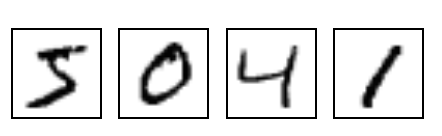

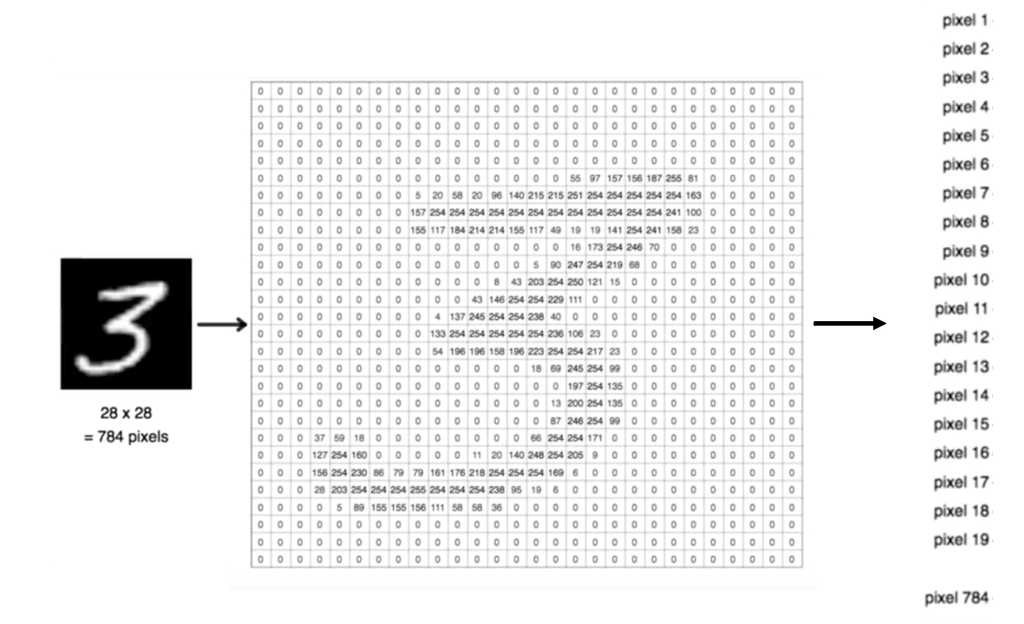

More here

- http://yann.lecun.com/exdb/mnist/

We will use the MNIST dataset to create a multinomial classifier that can detect whether the image belongs to one of the classes: 0, 1, 2, 3, 4, 5, 6, 7, 8, or 9. In short, we're teaching a computer to recognize handwritten digits.

```python
import numpy as np
import matplotlib.pyplot as plt
import tensorflow as tf
%matplotlib inline
```

Let's download and load the dataset.

```python
mnist = tf.keras.datasets.mnist

(train_x, train_y), (test_x, test_y) = mnist.load_data()

train_x, test_x = train_x/255.0, test_x/255.0
```

```
Downloading data from https://storage.googleapis.com/tensorflow/tf-keras-datasets/mnist.npz
```

```python
print ("The training data set is:\n")
print (train_x.shape)
print (train_y.shape)
```

```
The training data set is:

(60000, 28, 28)
(60000,)
```

```python
print ("The test data set is:")
print (test_x.shape)
print (test_y.shape)
```

```
The test data set is:
(10000, 28, 28)
(10000,)
```

Display a few random samples from it:

```python
# So now we have a 28x28 matrix, where each element is an intensity level from 0 to 1.

img = train_x[5]
img.shape
```

```
(28, 28)
```

Let's visualize what some of these images and their corresponding training labels look like.

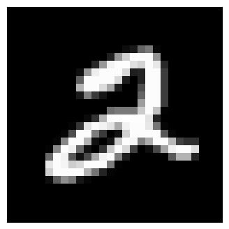

```python
plt.figure(figsize = (4, 4))
plt.imshow(img, 'gray')
plt.xticks([])
plt.yticks([])
plt.show()
```

```python
train_y[5]
```

```
2
```

## 7.2. ANN with TensorFlow

- Feed a gray image to ANN

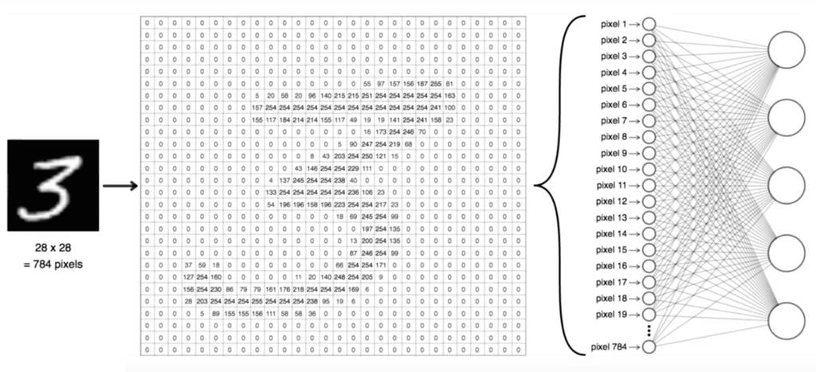

- Our network model
  - The hyperparameters of the network have not been optimized.
  - This example is intended solely to demonstrate how to implement the network in Python based on the provided structure.

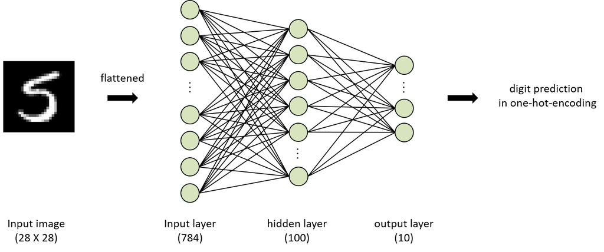

- Network training (learning)
  - Forward Pass: Input $X$ passes through the network to generate $\hat Y$.
  - Loss Calculation: The loss function compares $\hat Y$ and $Y$.
  - Backward Pass: The optimizer computes gradients of the loss concerning the weights.
  - Weight Update: Weights are adjusted based on the gradients.
  - Repeat: The process continues until the loss converges or the training reaches a predefined number of iterations.

$$\omega:= \omega - \alpha \nabla_{\omega} \left( h_{\omega} \left(x^{(i)}\right),y^{(i)}\right)$$

### 7.2.1. Import Library

```python
import numpy as np
import matplotlib.pyplot as plt
import tensorflow as tf
```

### 7.2.2. Load MNIST Data

- Download MNIST data from tensorflow tutorial example

```python
mnist = tf.keras.datasets.mnist

(train_x, train_y), (test_x, test_y) = mnist.load_data()
train_x, test_x = train_x/255.0, test_x/255.0
```

### 7.2.3. Define an ANN Structure

- Input size
- Hidden layer size
- The number of classes

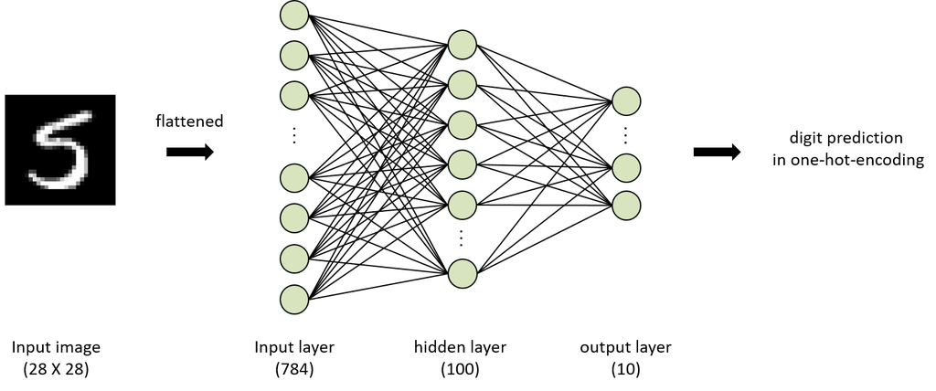

```python
model = tf.keras.models.Sequential([
    tf.keras.layers.Flatten(input_shape = (28, 28)),
    tf.keras.layers.Dense(units = 100, activation = 'relu'),
    tf.keras.layers.Dense(units = 10, activation = 'softmax')
])
```

### 7.2.4. Define Loss and Optimizer

**Optimizer**

- This defines how the model is updated based on the data it sees and its loss function.
- AdamOptimizer: the most popular optimizer

**Loss**

- This defines how we measure how accurate the model is during training. As was covered in lecture, during training we want to minimize this function, which will "steer" the model in the right direction.
- Classification: Cross-entropy
  - Equivalent to apply logistic regression

$$ -\frac{1}{m}\sum_{i=1}^{m}y^{(i)}\log(h_{\theta}\left(x^{(i)}\right)) + (1-y^{(i)})\log(1-h_{\theta}\left(x^{(i)}\right)) $$

**Metrics**

- Here we can define metrics used to monitor the training and testing steps. In this example, we'll look at the accuracy, the fraction of the images that are correctly classified.

```python
model.compile(optimizer = 'adam',
              loss = 'sparse_categorical_crossentropy',
              metrics = ['accuracy'])
```

### 7.2.5. Train Model

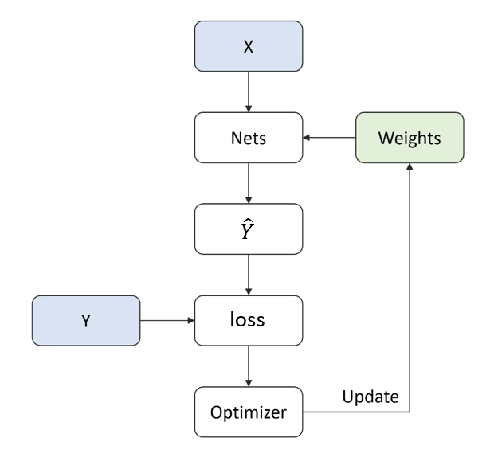

```python
# Train Model

loss = model.fit(train_x, train_y, epochs = 5)
```

### 7.2.6. Test or Evaluate

```python
# Evaluate Test Data

test_loss, test_acc = model.evaluate(test_x, test_y)
```

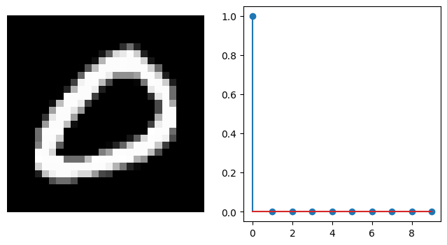

```
Prediction : 0
```

```python
test_img = test_x[np.random.choice(test_x.shape[0], 1)]

predict = model.predict_on_batch(test_img)
mypred = np.argmax(predict, axis = 1)

plt.figure(figsize = (8,4))

plt.subplot(1,2,1)
plt.imshow(test_img.reshape(28, 28), 'gray')
plt.axis('off')
plt.subplot(1,2,2)
plt.stem(predict[0])
plt.show()

print('Prediction : {}'.format(mypred[0]))
```

What is the highest accuracy you can achieve with this first fully connected model? Since the handwritten digit classification task is pretty straightforward, you may be wondering how we can do better...

$\Rightarrow$ As we saw in lecture, convolutional neural networks (CNNs) are particularly well-suited for a variety of tasks in computer vision, and have achieved near-perfect accuracies on the MNIST dataset. We will build a CNN and ultimately output a probability distribution over the 10 digit classes (0-9) in the next lectures.

## 7.3. Historial Notes

**The MNIST Dataset and Yann LeCun**

The MNIST (Modified National Institute of Standards and Technology) dataset is one of the most famous benchmark datasets in machine learning, consisting of 60,000 training images and 10,000 test images of handwritten digits (0 to 9), each in a 28x28 grayscale pixel format. It is widely used for training and evaluating classification models, especially in the field of neural networks.

**Yann LeCun’s Role in the Creation of MNIST**

Yann LeCun (Turing Award, 2018), a pioneer in the field of deep learning, created the MNIST dataset in collaboration with Corinna Cortes and Christopher J.C. Burges in 1998. LeCun, known for his groundbreaking work in neural networks, particularly convolutional neural networks (CNNs), developed MNIST as an easily accessible and standardized dataset to evaluate machine learning algorithms.

Before MNIST, many machine learning models struggled with inconsistent and poorly standardized datasets for real-world pattern recognition tasks. MNIST solved this by providing a well-curated, balanced, and preprocessed dataset that became the de facto benchmark for evaluating classification models.

**Legacy of MNIST**

Despite its simplicity, MNIST remains a crucial stepping stone in the history of artificial intelligence. It demonstrated the power of neural networks in pattern recognition and inspired the development of modern deep learning architectures. Yann LeCun’s creation of MNIST not only provided a foundational benchmark for machine learning but also played a pivotal role in popularizing neural networks and shaping the trajectory of modern AI research.

# 8. More in ANN

```python
from IPython.display import YouTubeVideo
YouTubeVideo('Jz7zrwoesBw', width="560", height="315", frameborder="0")
```

[video not shown]

## 8.1. Vanishing Gradient Problem

The vanishing gradient problem is a common issue in deep neural networks, where the gradients of the loss function become increasingly small as they are backpropagated through the network's layers. This leads to extremely small weight updates during training, especially for the earlier layers of the network, making learning inefficient or causing it to stall altogether.

**How Nonlinear Activation Functions Contribute to the Vanishing Gradient Problem**

Sigmoid and Tanh Activation Functions:

- The sigmoid function squashes its input into a range between 0 and 1:

$$ \sigma(x) = \frac{1}{1 + e^{-x}} $$

- The tanh function squashes its input into a range between -1 and 1:

$$ \tanh(x) = \frac{e^{x} - e^{-x}}{e^{x} + e^{-x}} $$

- In both cases, when the input values are very large (positive or negative), the gradients (derivatives) approach zero due to the flatness of the function at the extremes:

$$ \begin{align*} \sigma'(x) &= \sigma(x)(1 - \sigma(x)) \\\\ \tanh'(x) &= 1 - \tanh^2(x) \end{align*} $$

- For values close to 1 or 0, these derivatives become extremely small, which leads to small gradients during backpropagation.

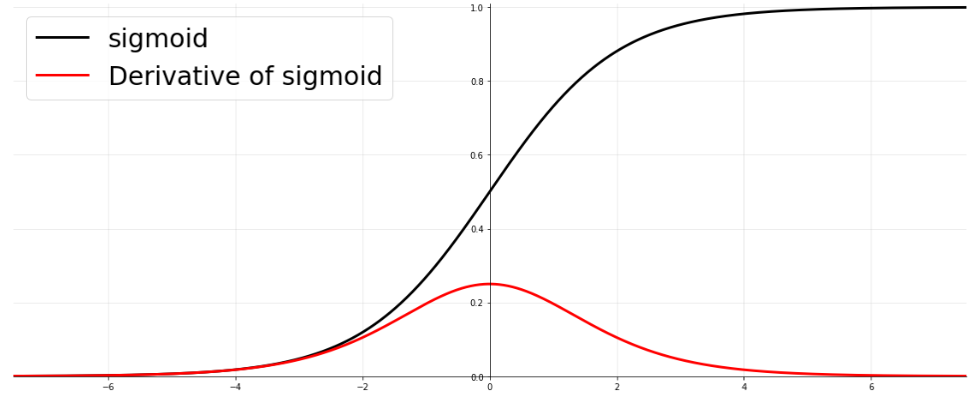

Effect on Deep Networks:

- As gradients propagate backward through the layers, they are multiplied by the derivatives of the activation functions at each layer.
- If the derivatives are small (close to zero), the product of gradients diminishes exponentially as the number of layers increases.
- This results in gradients that "vanish," making weight updates negligible, especially for early layers, effectively preventing the network from learning meaningful features.
- Chain rule

$$\frac{z}{u} = \frac{z}{y} \cdot \frac{y}{x} \cdot \frac{x}{\omega} \cdot \frac{\omega}{u} $$

## 8.2. Solutions to the Vanishing Gradient Problem

**(1) ReLU (Rectified Linear Unit)**

- The ReLU activation function:

$$\text{ReLU}(x) = \max(0,x)$$

- The derivative is 1 for positive inputs and 0 for negative inputs, avoiding the problem of very small gradients in most cases.
- ReLU allows gradients to flow more effectively in deep networks, improving convergence during training.
- The use of the ReLU activation function was a great improvement compared to the tanh.

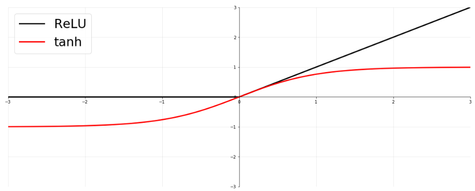

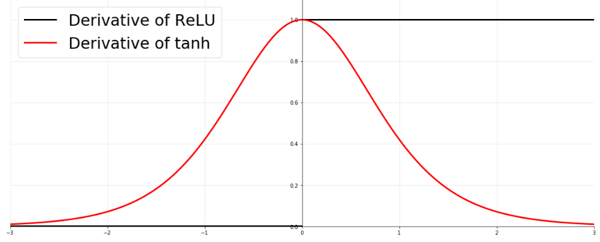

**(2) Batch Normalization**

Batch Normalization is a technique used to normalize the inputs to each layer in a neural network during training. By maintaining the mean and variance of the inputs at stable levels, Batch Normalization helps prevent issues like the vanishing gradient problem, which can severely affect the training of deep neural networks.

- Normalizes the input to each layer, keeping activations within a range that prevents gradients from becoming too small or too large.
- It is used to normalize the input layer by adjusting and scaling the activations.

How Batch Normalization Works

Batch Normalization normalizes the input for each mini-batch to have a mean of 0 and a standard deviation of 1. This helps keep the activations within a range where gradients can flow effectively, mitigating the vanishing gradient issue.

1. Normalization: For each mini-batch, compute the mean $ \mu_B $ and variance $ \sigma_B^2 $ of the batch:
   $$ \mu_B = \frac{1}{m} \sum_{i=1}^{m} x_i \quad \text{and} \quad \sigma_B^2 = \frac{1}{m} \sum_{i=1}^{m} (x_i - \mu_B)^2 $$
   where $ m $ is the number of examples in the batch.
2. Standardization: Normalize each input $ x_i $:

   $$ \hat{x}_i = \frac{x_i - \mu_B}{\sqrt{\sigma_B^2 + \epsilon}} $$

   where $ \epsilon $ is a small constant added for numerical stability.
3. Scale and Shift: Introduce learnable parameters $ \gamma $ (scale) and $ \beta $ (shift) to allow the network to recover flexibility:

   $$ y_i = \gamma \hat{x}_i + \beta $$

   This enables the network to learn the appropriate distribution of the normalized outputs.

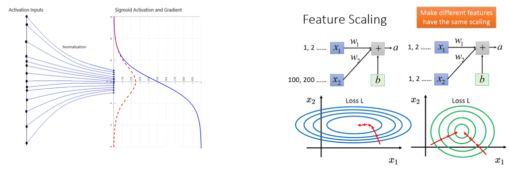

- During training batch normalization shifts and rescales according to the mean and variance estimated on the batch.
- During test, it simply shifts and rescales according to the empirical moments estimated during training.

```python
import numpy as np
import matplotlib.pyplot as plt
import tensorflow as tf
```

**Overfitting in Regression**

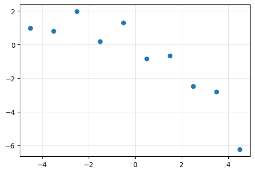

```python
N = 10
data_x = np.linspace(-4.5, 4.5, N)
data_y = np.array([0.9819, 0.7973, 1.9737, 0.1838, 1.3180, -0.8361, -0.6591, -2.4701, -2.8122, -6.2512])

data_x = data_x.reshape(-1,1)
data_y = data_y.reshape(-1,1)

plt.figure(figsize = (6, 4))
plt.plot(data_x, data_y, 'o')
plt.grid(alpha = 0.3)
plt.show()
```

```python
base_model = tf.keras.models.Sequential([
    tf.keras.layers.Dense(input_shape = (1,),
                          units = 30, activation = 'sigmoid'),
    tf.keras.layers.Dense(units = 100, activation = 'sigmoid'),
    tf.keras.layers.Dense(units = 100, activation = 'sigmoid'),
    tf.keras.layers.Dense(units = 30, activation = 'sigmoid'),
    tf.keras.layers.Dense(units = 1, activation = None)
])
```

```python
base_model.compile(optimizer = tf.keras.optimizers.Adam(0.001),
                   loss = 'mse',
                   metrics = ['mse'])
```

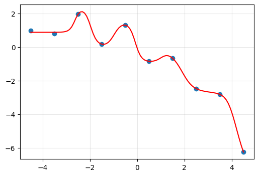

```python
# Train Model & Evaluate Test Data

training = base_model.fit(data_x, data_y, epochs = 5000, verbose = 0)

xp = np.linspace(-4.5, 4.5, 100).reshape(-1,1)
my_pred = base_model.predict(xp)

plt.figure(figsize = (6, 4))
plt.plot(data_x, data_y, 'o')
plt.plot(xp, my_pred, 'r')
plt.grid(alpha = 0.3)
plt.show()
```

**Batch Normalization Implementation**

This example is not intended to demonstrate the improvement in performance and stability of artificial neural networks achieved through batch normalization, but rather to illustrate how to implement batch normalization using TensorFlow 2

```python
bn_model = tf.keras.models.Sequential([
    tf.keras.layers.Dense(units = 30, activation = None, input_shape = (1,)),
    tf.keras.layers.BatchNormalization(),
    tf.keras.layers.Activation('sigmoid'),
    tf.keras.layers.Dense(units = 100, activation = None),
    tf.keras.layers.BatchNormalization(),
    tf.keras.layers.Activation('sigmoid'),
    tf.keras.layers.Dense(units = 100, activation = None),
    tf.keras.layers.BatchNormalization(),
    tf.keras.layers.Activation('sigmoid'),
    tf.keras.layers.Dense(units = 30, activation = None),
    tf.keras.layers.BatchNormalization(),
    tf.keras.layers.Activation('sigmoid'),
    tf.keras.layers.Dense(units = 1, activation = None)
])
```

```python
bn_model.compile(optimizer = tf.keras.optimizers.Adam(0.001),
                 loss = 'mse',
                 metrics = ['mse'])
```

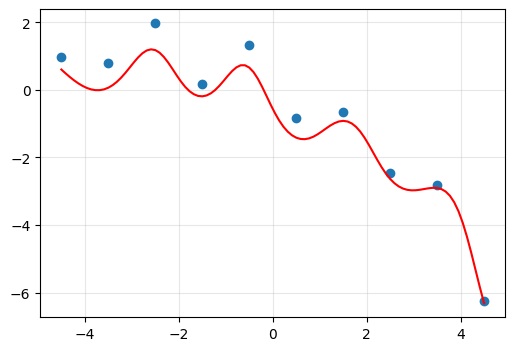

```python
training = bn_model.fit(data_x, data_y, epochs = 4000, verbose = 0)

xp = np.linspace(-4.5, 4.5, 100).reshape(-1,1)
my_pred = bn_model.predict(xp)

plt.figure(figsize = (6, 4))
plt.plot(data_x, data_y, 'o')
plt.plot(xp, my_pred, 'r')
plt.grid(alpha = 0.3)
plt.show()
```

Batch Normalization is primarily known for stabilizing and accelerating the training of deep neural networks by normalizing the inputs to each layer. Interestingly, Batch Normalization also has an impact on overfitting — a phenomenon where the model performs well on the training data but poorly on unseen data.

- Since BatchNorm normalizes activations, the network does not need excessively large weights to produce meaningful outputs.
- This reduces the risk of overfitting caused by excessively large parameter values.

## 8.3. Dropout as Regularization

We have learned that there are numerous techniques available to prevent overfitting, such as regularization, dropout, data augmentation, and early stopping, which are commonly used strategies in deep learning.

Dropout is a regularization technique used in neural networks to prevent overfitting by randomly "dropping" a fraction of neurons during training. This forces the network to learn more robust and distributed representations, rather than relying too heavily on specific neurons.

- This is the one of the most interesting types of regularization techniques.
- It also produces very good results and is consequently the most frequently used regularization technique in the field of deep learning.
- At every iteration, it randomly selects some nodes and removes them.
- It can also be thought of as an ensemble technique in machine learning.

**How Dropout Works**

Training Phase:

- During each training iteration, a random set of neurons in the network is temporarily "dropped" with a probability $p$ (known as the dropout rate).
- This means that the corresponding connections to those neurons do not participate in forward or backward passes for that iteration.

Testing/Inference Phase:

- During testing or inference, dropout is turned off, and the full network is used. However, the weights of the remaining neurons are scaled to account for the dropped connections during training:

- This ensures that the outputs remain consistent even when dropout is no longer applied.

**Why Dropout Prevents Overfitting**

- Breaks Co-Adaptation:
  - By randomly disabling neurons, dropout prevents the network from becoming overly reliant on specific neurons, forcing the remaining neurons to learn more robust features.
- Reduces Model Complexity:
  - Effectively, dropout creates an ensemble of different "sub-networks" during training, making it harder for the model to overfit to the training data.
- Adds Noise to Training:
  - The randomness introduced by dropout acts as noise, which can improve the network's generalization performance.

**Dropout Implementation**

```python
dropout_model = tf.keras.models.Sequential([
    tf.keras.layers.Dense(input_shape = (1,),
                          units = 30, activation = 'sigmoid'),
    tf.keras.layers.Dropout(rate = 0.2),
    tf.keras.layers.Dense(units = 100, activation = 'sigmoid'),
    tf.keras.layers.Dropout(rate = 0.2),
    tf.keras.layers.Dense(units = 100, activation = 'sigmoid'),
    tf.keras.layers.Dropout(rate = 0.2),
    tf.keras.layers.Dense(units = 30, activation = 'sigmoid'),
    tf.keras.layers.Dropout(rate = 0.2),
    tf.keras.layers.Dense(units = 1, activation = None)
])
```

```python
dropout_model.compile(optimizer = tf.keras.optimizers.Adam(0.001),
                      loss = 'mse',
                      metrics = ['mse'])
```

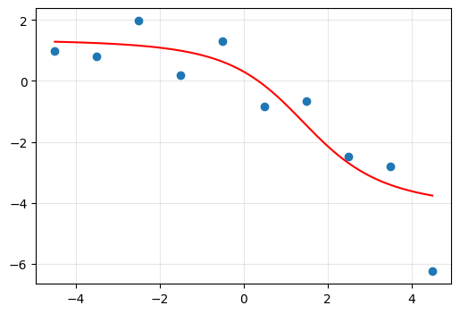

```python
training = dropout_model.fit(data_x, data_y, epochs = 200, verbose = 0)

xp = np.linspace(-4.5, 4.5, 100).reshape(-1,1)
my_pred = dropout_model.predict(xp)

plt.figure(figsize = (6, 4))
plt.plot(data_x, data_y, 'o')
plt.plot(xp, my_pred, 'r')
plt.grid(alpha = 0.3)
plt.show()
```

- In this example, a 20% dropout rate is applied to all layers, meaning that 20% of the neurons are randomly disabled during training.
- During inference, all neurons are utilized, but their outputs are scaled appropriately to account for the dropout during training.

# 9. Other Tutorials

```python
%%html
<iframe src="https://www.youtube.com/embed/aircAruvnKk?rel=0"
width="560" height="315" frameborder="0" allowfullscreen></iframe>
```

[video not shown]

```python
%%html
<iframe src="https://www.youtube.com/embed/IHZwWFHWa-w?rel=0"
width="560" height="315" frameborder="0" allowfullscreen></iframe>
```

[video not shown]

```python
%%html
<iframe src="https://www.youtube.com/embed/Ilg3gGewQ5U?rel=0"
width="560" height="315" frameborder="0" allowfullscreen></iframe>
```

[video not shown]

```python
%%html
<iframe src="https://www.youtube.com/embed/tIeHLnjs5U8?rel=0"
width="560" height="315" frameborder="0" allowfullscreen></iframe>
```

[video not shown]

```python
%%javascript
$.getScript('https://kmahelona.github.io/ipython_notebook_goodies/ipython_notebook_toc.js')
```